# Hoja de Trabajo 1. Análisis Exploratorio

### Grupo 7

#### Pablo Gonzalez, Jose Hernandez, Javier Mombiela

```python
import pandas as pd
import matplotlib.pyplot as plt
from IPython.display import display
```

```python
df = pd.read_csv("movies.csv", encoding= 'unicode_escape')
```

## 1. (3 puntos) Haga una exploración rápida de sus datos, para eso haga un resumen de su conjunto de datos.

```python
print(df.describe())
print(df.info())
print(df.tail())
```

```
                  id        budget       revenue       runtime    popularity  \
count   10000.000000  1.000000e+04  1.000000e+04  10000.000000  10000.000000
mean   249876.829300  1.855163e+07  5.673793e+07    100.268100     51.393907
std    257380.109004  3.662669e+07  1.495854e+08     27.777829    216.729552
min         5.000000  0.000000e+00  0.000000e+00      0.000000      4.258000
25%     12286.500000  0.000000e+00  0.000000e+00     90.000000     14.577750
50%    152558.000000  5.000000e+05  1.631245e+05    100.000000     21.905500
75%    452021.750000  2.000000e+07  4.479661e+07    113.000000     40.654000
max    922260.000000  3.800000e+08  2.847246e+09    750.000000  11474.647000

            voteAvg     voteCount  genresAmount  productionCoAmount  \
count  10000.000000  10000.000000  10000.000000        10000.000000
mean       6.483490   1342.381800      2.596500            3.171400
std        0.984274   2564.196637      1.154565            2.539738
min        1.300000      1.000000      0.000000            0.000000
25%        5.900000    120.000000      2.000000            2.000000
50%        6.500000    415.000000      3.000000            3.000000
75%        7.200000   1316.000000      3.000000            4.000000
max       10.000000  30788.000000     16.000000           89.000000

       productionCountriesAmount   actorsAmount
count               10000.000000   10000.000000
mean                    1.751000    2147.666600
std                     3.012093   37200.075802
min                     0.000000       0.000000
25%                     1.000000      13.000000
50%                     1.000000      21.000000
75%                     2.000000      36.000000
max                   155.000000  919590.000000
<class 'pandas.core.frame.DataFrame'>
RangeIndex: 10000 entries, 0 to 9999
Data columns (total 27 columns):
 #   Column                     Non-Null Count  Dtype
---  ------                     --------------  -----
 0   id                         10000 non-null  int64
 1   budget                     10000 non-null  int64
 2   genres                     9947 non-null   object
 3   homePage                   4193 non-null   object
 4   productionCompany          9543 non-null   object
 5   productionCompanyCountry   8720 non-null   object
```

[output cut: 59 more lines]

```
     productionCountriesAmount  actorsAmount castWomenAmount  \
9995                         1            10               2
9996                         1             8               1
9997                        17             1               0
9998                         0             0          922162
9999                         1             8               4

               castMenAmount
9995                       4
9996                       1
9997                  922017
9998  The Witcher: Fireplace
9999                       3

[5 rows x 27 columns]
```

## 2. (5 puntos) Diga el tipo de cada una de las variables (cualitativa ordinal o nominal, cuantitativa continua, cuantitativa discreta)

"id" - cuantitativa discreta (identificador único)

"budget" - cuantitativa continua (valor numérico)

"genres" - cualitativa nominal (género o categoría sin orden)

"homePage" - cualitativa nominal (URL)

"production Company" - cualitativa nominal (nombre de la compañía de producción)

"production Company Country" - cualitativa nominal (país de origen de la compañía de producción)

"production Country" - cualitativa nominal (país de producción)

"revenue" - cuantitativa continua (valor numérico)

"runtime" - cuantitativa discreta (duración en minutos)

"video" - cualitativa nominal (sí/no)

"director" - cualitativa nominal (nombre del director)

"actors" - cualitativa nominal (nombre de los actores)

"actors Popularity" - cuantitativa continua (valor numérico)

"actors Character" - cualitativa nominal (personaje del actor)

"original Title" - cualitativa nominal (título original)

"title" - cualitativa nominal (título traducido)

"original Language" - cualitativa nominal (idioma original)

"popularity" - cuantitativa continua (valor numérico)

"release Date" - cualitativa nominal (fecha de lanzamiento)

"voteAvg" - cuantitativa continua (valor numérico)

"vote Count" - cuantitativa discreta (número de votos)

"genres Amount" - cuantitativa discreta (número de géneros)

"production Co Amount" - cuantitativa discreta (número de compañías de producción)

"production Countries Amount" - cuantitativa discreta (número de países de producción)

"actors Amount" - cuantitativa discreta (número de actores)

"castWomenAmount" - cuantitativa discreta (número de actores femeninos)

"castMenAmount" - cuantitativa discreta (número de actores masculinos)

## 4. 1 (3 puntos) ¿Cuáles son las 10 películas que contaron con más presupuesto?

```python
# leer el archivo csv y guardar en un dataframe
df = pd.read_csv('movies.csv', encoding= 'unicode_escape')

# ordenar el dataframe por la columna 'budget' en forma descendente
df = df.sort_values(by='budget', ascending=False)

# seleccionar las primeras 10 filas
top_10 = df.head(10)

# imprimir las 10 películas con más presupuesto
print("Las 10 películas con más presupuesto son:")
print(top_10[['title', 'budget']])
```

```
Las 10 películas con más presupuesto son:
                                            title     budget
716   Pirates of the Caribbean: On Stranger Tides  380000000
4710                      Avengers: Age of Ultron  365000000
5952                            Avengers: Endgame  356000000
4953                               Justice League  300000000
5953                       Avengers: Infinity War  300000000
163      Pirates of the Caribbean: At World's End  300000000
607                              Superman Returns  270000000
7134                                The Lion King  260000000
3791                                      Tangled  260000000
280                                  Spider-Man 3  258000000
```

## 4. 2 (3 puntos) ¿Cuáles son las 10 películas que más ingresos tuvieron?

```python
# ordenar el dataframe por la columna 'budget' en forma descendente
df = df.sort_values(by='revenue', ascending=False)

# seleccionar las primeras 10 filas
top_10 = df.head(10)

# imprimir las 10 películas con más presupuesto
print("Las 10 películas con más recaudación son:")
print(top_10[['title', 'revenue']])
```

```
Las 10 películas con más recaudación son:
                             title       revenue
3210                        Avatar  2.847246e+09
5952             Avengers: Endgame  2.797801e+09
307                        Titanic  2.187464e+09
4947  Star Wars: The Force Awakens  2.068224e+09
5953        Avengers: Infinity War  2.046240e+09
4914                Jurassic World  1.671713e+09
7134                 The Lion King  1.667635e+09
9049       Spider-Man: No Way Home  1.631853e+09
3397                  The Avengers  1.518816e+09
5087                     Furious 7  1.515048e+09
```

## 4. 3 (3 puntos) ¿Cuál es la película que más votos tuvo?

```python
# ordenar el dataframe por la columna 'voteCount' en forma descendente
df = df.sort_values(by='voteCount', ascending=False)

# seleccionar la primera fila
top_1 = df.iloc[0]

# imprimir la película con más votos

print("La película con más votos fue " + str(top_1['title']) + " con " + str(top_1['voteCount']) + " votos.")
# print(top_1[['title', 'voteCount']])
```

```
La película con más votos fue Inception con 30788 votos.
```

## 4. 4 (3 puntos) ¿Cuál es la peor película de acuerdo a los votos de todos los usuarios?

```python
# ordenar el dataframe por la columna 'voteAvg' en forma ascendente
df = df.sort_values(by='voteAvg')

# seleccionar la primera fila
worst = df.iloc[0]

# imprimir la peor película de acuerdo a los votos
print("La pelicula con peor calificación fue " + str(worst['title']) + " con " + str(worst['voteAvg']) + " puntos.")

# print(worst[['title', 'voteAvg']])
```

```
La pelicula con peor calificación fue DAKAICHI -I'm Being Harassed by the Sexiest Man of the Year- The Movie: In Spain con 1.3 puntos.
```

## 4.5 (8 puntos) ¿Cuántas películas se hicieron en cada año? ¿En qué año se hicieron más películas? Haga un gráfico de barras

```
             title
releaseDate
1902             1
1920             1
1921             1
1922             1
1925             2
...            ...
2018           629
2019           612
2020           533
2021           816
2022             7

[99 rows x 1 columns]
Año con más películas: 2021
```

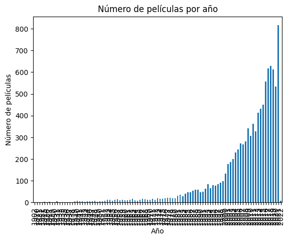

```python
# convertir la columna 'releaseDate' a tipo fecha
df['releaseDate'] = pd.to_datetime(df['releaseDate'], format='%Y/%m/%d')

# agrupar por año y contar el número de películas por año
movies_by_year = df.groupby(df['releaseDate'].dt.year).count()

# imprimir el número de películas por año
print(movies_by_year[['title']])

# calcular el año con más películas
most_movies_year = movies_by_year['title'].idxmax()
print(f"Año con más películas: {most_movies_year}")

# grafico de barras
movies_by_year['title'].plot(kind='bar')
plt.xlabel('Año')
plt.ylabel('Número de películas')
plt.title('Número de películas por año')
plt.xticks(rotation=90)
plt.show()
```

## 4.6. (9 puntos) ¿Cuál es el género principal de las 20 películas más recientes? ¿Cuál es el género principal que predomina en el conjunto de datos? Represéntelo usando un gráfico.

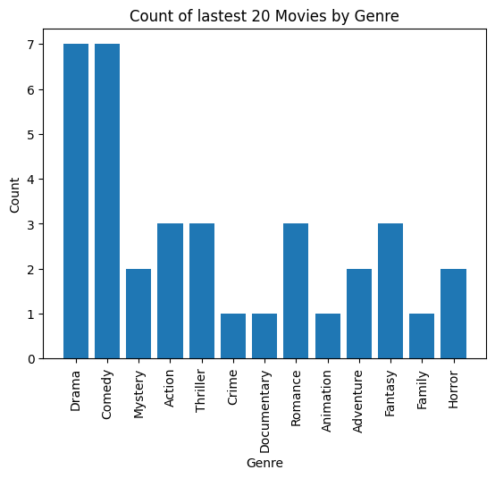

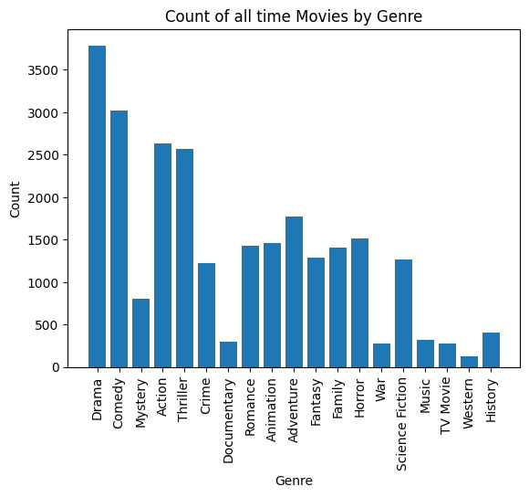

```python
# convertir la columna 'releaseDate' a tipo fecha
df['releaseDate'] = pd.to_datetime(df['releaseDate'], format='%Y/%m/%d')

prueba = df.sort_values(by='releaseDate', ascending=False)

ultimas20 = prueba[['releaseDate','title','genres']].head(20).dropna()

genres_list = ultimas20['genres'].str.split('|')

# print(ultimas20)

diccionario_generos = {}

for genre in genres_list:

    for entry in genre:

        diccionario_generos[entry] =  0

for genre in genres_list:

    for entry in genre:

        diccionario_generos[entry] =  diccionario_generos[entry] + 1

plt.bar(diccionario_generos.keys(), diccionario_generos.values())
plt.xlabel('Genre')
plt.ylabel('Count')
plt.title('Count of lastest 20 Movies by Genre')
plt.xticks(rotation=90)
plt.show()


todas = prueba[['releaseDate','title','genres']].dropna()
genres_list = todas['genres'].str.split('|')
diccionario_generos = {}
for genre in genres_list:

    for entry in genre:

        diccionario_generos[entry] =  0

for genre in genres_list:

    for entry in genre:

        diccionario_generos[entry] =  diccionario_generos[entry] + 1

plt.bar(diccionario_generos.keys(), diccionario_generos.values())
plt.xlabel('Genre')
plt.ylabel('Count')
plt.title('Count of all time Movies by Genre')
plt.xticks(rotation=90)
plt.show()
```

## 4.7 (8 puntos) ¿Las películas de qué genero principal obtuvieron mayores ganancias?

```python
temp = prueba[['title','genres','revenue']].dropna()

print(temp)
```

```
                            title                             genres  \
9516      A Shot Through the Wall                              Drama
9545                      Presque                       Comedy|Drama
9197              Italian Studies                      Drama|Mystery
9586               American Siege        Action|Thriller|Crime|Drama
9808                   See for Me                           Thriller
...                           ...                                ...
526                 The Gold Rush             Adventure|Comedy|Drama
355                     Nosferatu               Drama|Fantasy|Horror
1800                      The Kid                       Comedy|Drama
133   The Cabinet of Dr. Caligari        Drama|Horror|Thriller|Crime
417            A Trip to the Moon  Adventure|Fantasy|Science Fiction

        revenue
9516        0.0
9545        0.0
9197        0.0
9586        0.0
9808        0.0
...         ...
526   4000000.0
355     19054.0
1800  2500000.0
133      8811.0
417         0.0

[9947 rows x 3 columns]
```

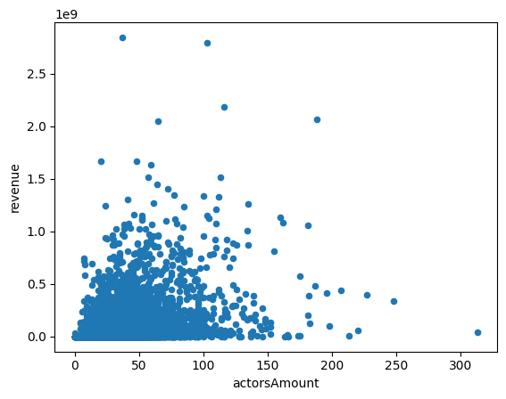

```python
# temp = prueba[['title','actorsAmount','revenue','genres']].dropna()
temp = prueba[['actorsAmount','revenue','genres']].dropna()


temp = temp.sort_values(by='actorsAmount', ascending=False)

# print(temp.head(20))

temp.plot.scatter(x='actorsAmount', y='revenue')
```

Como puede visualizar en la grafica previa, la dispersion no tiene ningun tipo de patron, ni tiende a seguir ningun comportamiento por lo que podemos asumir que la cantidad de actores no influencia directamente en que tantas ganancias tiene una pelicula.

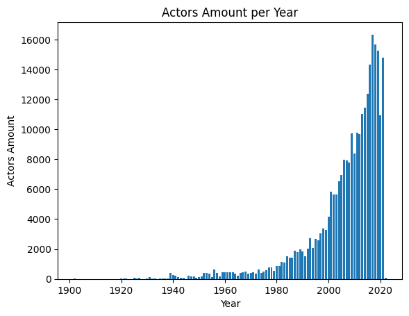

```python
temp = prueba[['actorsAmount','releaseDate','genres']].dropna().sort_values(by='releaseDate', ascending=False)

# print(temp.head(20).to_string(index=False))

temp['year'] = temp['releaseDate'].dt.year

grouped_df = temp.groupby('year').sum()

plt.bar(grouped_df.index, grouped_df['actorsAmount'])
plt.xlabel('Year')
plt.ylabel('Actors Amount')
plt.title('Actors Amount per Year')
plt.show()
```

Si hubo un incremento en el numero de actores conforme avanzaban las decadas pero en las ultimas entradas pero se puede ver que hay un comportamiento de decremento en los ultimos años desde el 2018.

# 4. 9 (3 puntos) ¿Es posible que la cantidad de hombres y mujeres en el reparto influya en la popularidad y los ingresos de las películas?

[output not shown]

[output cut: 46 more lines]

[output not shown]

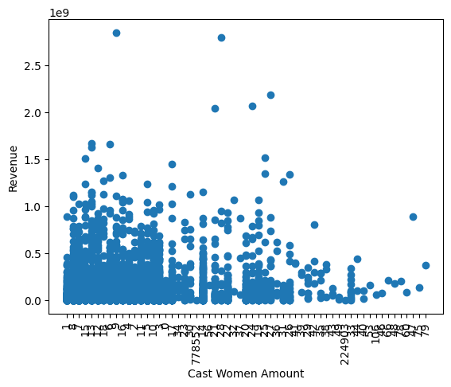

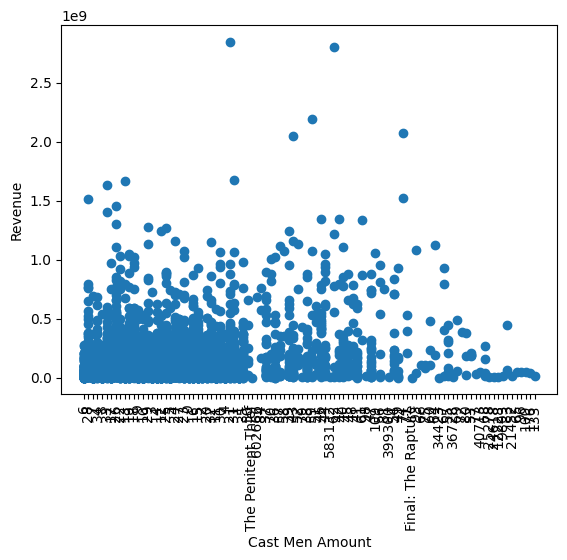

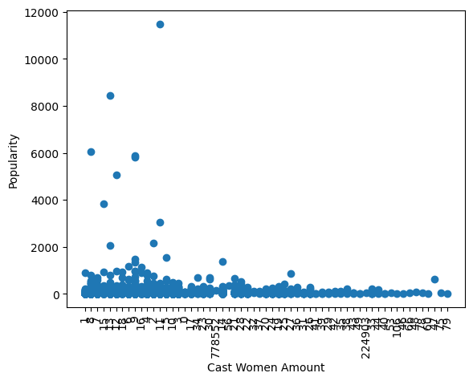

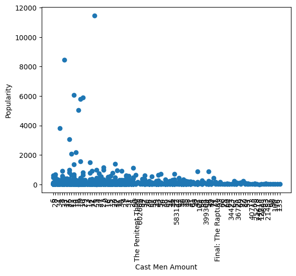

```python
dfhombre_mujeres = prueba[['revenue','popularity','castWomenAmount','castMenAmount','genres']].dropna()

dfhombre_mujeres = dfhombre_mujeres[dfhombre_mujeres.revenue != 0][['revenue','popularity','castWomenAmount','castMenAmount']]

# dfhombre_mujeres = dfhombre_mujeres[dfhombre_mujeres.castWomenAmount < 2000]
# dfhombre_mujeres = dfhombre_mujeres[dfhombre_mujeres.castMenAmount < 2000]

print(dfhombre_mujeres.head(100).to_string(index=False))

plt.scatter(dfhombre_mujeres['castWomenAmount'], dfhombre_mujeres['revenue'])
plt.xlabel('Cast Women Amount')
plt.xticks(rotation=90)
plt.ylabel('Revenue')
plt.show()

plt.scatter(dfhombre_mujeres['castMenAmount'], dfhombre_mujeres['revenue'])
plt.xlabel('Cast Men Amount')
plt.xticks(rotation=90)
plt.ylabel('Revenue')
plt.show()

plt.scatter(dfhombre_mujeres['castWomenAmount'], dfhombre_mujeres['popularity'])
plt.xlabel('Cast Women Amount')
plt.xticks(rotation=90)
plt.ylabel('Popularity')
plt.show()

plt.scatter(dfhombre_mujeres['castMenAmount'], dfhombre_mujeres['popularity'])
plt.xlabel('Cast Men Amount')
plt.xticks(rotation=90)
plt.ylabel('Popularity')
plt.show()
```

# 4. 10. (8 puntos) ¿Quiénes son los directores que hicieron las 20 películas mejor calificadas?

```python
dfdirectores = prueba[['voteAvg','director','genres']].dropna()
dfdirectores = dfdirectores[dfdirectores.voteAvg != 0][['voteAvg','director']]

dfdirectores = dfdirectores.sort_values(by='voteAvg', ascending=False)
# temp = temp.sort_values(by='actorsAmount', ascending=False)

print("Los directores que produjeron las 20 películas con mejor promedio de votos son:")
print(dfdirectores.head(20))
```

```
Los directores que produjeron las 20 películas con mejor promedio de votos son:
      voteAvg                                           director
9347     10.0                                       Kaku Arakawa
9298     10.0                                  Laurent Bouzereau
9733     10.0                                     Christin Baker
8632     10.0                                       Thomas Coven
9990     10.0                                Miguel Angel Zavala
9246     10.0                                      Rebecca Sugar
6885      9.6             Dave Bullock|Troy Adomitis|Victor Cook
6170      9.5                                       Samuel Leong
9368      9.5                                     Won Myeong-jun
5528      9.4                                 Selena Quintanilla
9783      9.3                                     Haruo Sotozaki
9756      9.3                                     Haruo Sotozaki
9219      9.2  Kim Nam-joon|Jeon Jung-kook|Kim Tae-hyung|Park...
9451      9.2                                       Park Jun-soo
8265      9.2                                    Ulises Valencia
9777      9.2                                       Igor Kopylov
8884      9.1                                       Park Jun-soo
6303      9.0                                     Filip Ghiorghi
5817      9.0                                     Michael Goguen
9648      9.0                             Preston A. Whitmore II
```

# 4.11. (8 puntos) ¿Cómo se correlacionan los presupuestos con los ingresos? ¿Los altos presupuestos significan altos ingresos? Haga los gráficos que necesite, histograma, diagrama de dispersión

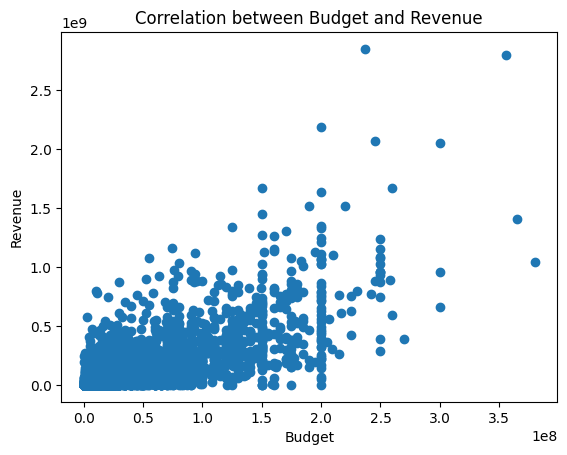

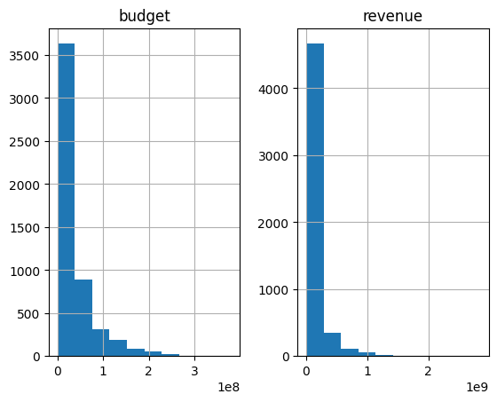

```python
df_budgets = prueba[['budget','revenue','genres']].dropna()

df_budgets = df_budgets[df_budgets.budget != 0][['budget','revenue']]

plt.scatter(df_budgets['budget'], df_budgets['revenue'])
plt.xlabel('Budget')
plt.ylabel('Revenue')
plt.title('Correlation between Budget and Revenue')
plt.show()

df_budgets.hist(bins=10)
plt.show()

# print(df_budgets.head(100).to_string(index=False))
```

Desde el diagrama de dispersión podemos ver que hay una correlación positiva entre presupuestos y ingresos, pero también hay casos con presupuestos altos y ingresos bajos, lo que indica que no siempre un presupuesto alto garantiza ingresos altos. Además, los histogramas muestran la distribución de valores para cada columna.

# 4.12 (7 puntos) ¿Se asocian ciertos meses de lanzamiento con mejores ingresos?

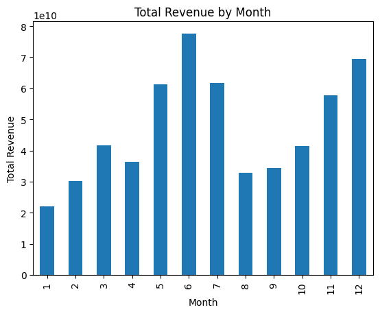

```python
df_months = prueba[['releaseDate','revenue','genres']].dropna()

df_months = df_months[df_months.revenue != 0][['releaseDate','revenue']]

# Extraer el mes de releaseDate
df_months['month'] = df_months['releaseDate'].dt.month

# Agrupar por mes y calcular la suma de ingresos
monthly_revenue = df_months.groupby('month')['revenue'].sum()

# Imprimir resultados
# print(monthly_revenue)

# Crear gráfica de barras
monthly_revenue.plot(kind='bar')

# Añadir título y etiquetas de ejes
plt.title('Total Revenue by Month')
plt.xlabel('Month')
plt.ylabel('Total Revenue')

# Mostrar gráfica
plt.show()

# print(df_months.head(20).to_string(index=False))
```

Se puede ver que los mese con mejor ingreso son Junio y Diciembre que son normalmente los meses de estreno de peliculas de verano y navidad respectivamente. Esto puede ser debido a que son meses de vacaciones por lo que las personas tienen mas tiempo libre para ir al cine. Al igual que los meses de mayo y julio que son meses de estreno de peliculas en epoca de verano.

# 4.13 (8 puntos) ¿En qué meses se han visto los lanzamientos con mejores ingresos?¿cuantas películas, en promedio, se han lanzado por mes?

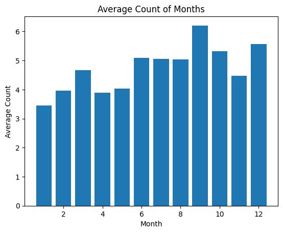

```python
df_real_month = prueba[['releaseDate','revenue','genres']].dropna()

df_real_month = df_real_month[df_real_month.revenue != 0][['releaseDate']]

grouped = df_real_month.groupby(df_real_month['releaseDate'].dt.year)

# Contar la frecuencia de cada mes
month_counts = {}
for name, group in grouped:
    month_counts[name] = group['releaseDate'].dt.month.value_counts().to_dict()

# Hacer la media de los conteos de meses
total_months = {}
for year, counts in month_counts.items():
    for month, count in counts.items():
        if month not in total_months:
            total_months[month] = count
        else:
            total_months[month] += count

# Dividir la suma de los conteos de cada mes por el número de años
average_months = {month: count / len(month_counts) for month, count in total_months.items()}


# Ordenar el diccionario y graficar los resultados
sorted_months = sorted(average_months.items(), key=lambda x: x[1], reverse=True)
months, counts = zip(*sorted_months)

plt.bar(months, counts)
plt.xlabel('Month')
plt.ylabel('Average Count')
plt.title('Average Count of Months')
plt.show()
```

Dado el inciso anterior se puede ver que los meses con mejores ingresos son los meses de vacaciones como junio y diciembre.

Basado en el grafico de mes contra promedio de lanzamientos, se puede ver que los meses con mayores lanzamientos son septiembre y diciembre.

# 4. 14. (7 puntos) ¿Cómo se correlacionan las calificaciones con el éxito comercial?

```python
dataframe_temporal = prueba[['title','genres','popularity','voteAvg']].dropna()

dataframe_temporal = prueba[['title','popularity','voteAvg']]

print(dataframe_temporal.head(10).to_string(index=False))

display(dataframe_temporal.head(10))
```

```
                                            title  popularity  voteAvg
                          A Shot Through the Wall      40.483      7.0
                                          Presque      10.455      7.0
                                  Italian Studies      12.613      4.5
                                   American Siege      49.841      6.3
                                       See for Me      19.144      5.6
Harry Potter 20th Anniversary: Return to Hogwarts     856.038      8.4
                                   WWE Day 1 2022      14.341      7.5
                               Karem, La Posesión      92.973      2.0
                      Gabriel's Rapture: Part One      28.056      8.1
                                 Return of Chucky      41.676      5.3
```

|  | title | popularity | voteAvg |
| --- | --- | --- | --- |
| 9516 | A Shot Through the Wall | 40.483 | 7.0 |
| 9545 | Presque | 10.455 | 7.0 |
| 9197 | Italian Studies | 12.613 | 4.5 |
| 9586 | American Siege | 49.841 | 6.3 |
| 9808 | See for Me | 19.144 | 5.6 |
| 9982 | Harry Potter 20th Anniversary: Return to Hogwarts | 856.038 | 8.4 |
| 9951 | WWE Day 1 2022 | 14.341 | 7.5 |
| 9241 | Karem, La Posesión | 92.973 | 2.0 |
| 9866 | Gabriel's Rapture: Part One | 28.056 | 8.1 |
| 9257 | Return of Chucky | 41.676 | 5.3 |